# Course Project Description

3/16

Name: Jieying Li, 919349988

# Abstract:

# Introduction:

Many neuoscience research have shown significant progress such as studies like the Steinnetz et al (2019) which provided datasets for analysis. This project focuses on 18 sub datasets, consists for recordings from the visual cortex of the mice duirng trials that involve visual stimuli. Each session comprises multiple trials where mice are presented with stimuli of varying contrast on two screen. Their neural activity and decisions are recorded to offer detials for the relationship between neural activity patterns, stimulus contrasts, and trial outcome. The project aim to develop predictive models for trial outcome using neural activity and stimulus contrast data. There are three parts of the project whcih include: exploratory data analysis, data integration, and model training and prediction.

```
## [1] "Cori"
## [1] "2016-12-14"
## [1] "Cori"
## [1] "2016-12-17"
## [1] "Cori"
## [1] "2016-12-18"
## [1] "Forssmann"
## [1] "2017-11-01"
## [1] "Forssmann"
## [1] "2017-11-02"
## [1] "Forssmann"
## [1] "2017-11-04"
## [1] "Forssmann"
## [1] "2017-11-05"
## [1] "Hench"
```

[output cut: 21 more lines]

#Exploratory Analysis:

```r
suppressWarnings(library(tidyverse))
suppressWarnings(library(knitr))
suppressWarnings(library(dplyr))
suppressWarnings(library(caret))
suppressWarnings(library(reshape2))
suppressWarnings(library(pROC))
suppressWarnings(library(xgboost))
```

| mouse_name | date_exp | n_brain_area | n_neurons | n_trials | success_rate |
| --- | --- | --- | --- | --- | --- |
| Cori | 2016-12-14 | 8 | 734 | 114 | 0.61 |
| Cori | 2016-12-17 | 5 | 1070 | 251 | 0.63 |
| Cori | 2016-12-18 | 11 | 619 | 228 | 0.66 |
| Forssmann | 2017-11-01 | 11 | 1769 | 249 | 0.67 |
| Forssmann | 2017-11-02 | 10 | 1077 | 254 | 0.66 |
| Forssmann | 2017-11-04 | 5 | 1169 | 290 | 0.74 |
| Forssmann | 2017-11-05 | 8 | 584 | 252 | 0.67 |
| Hench | 2017-06-15 | 15 | 1157 | 250 | 0.64 |
| Hench | 2017-06-16 | 12 | 788 | 372 | 0.69 |
| Hench | 2017-06-17 | 13 | 1172 | 447 | 0.62 |
| Hench | 2017-06-18 | 6 | 857 | 342 | 0.80 |
| Lederberg | 2017-12-05 | 12 | 698 | 340 | 0.74 |
| Lederberg | 2017-12-06 | 15 | 983 | 300 | 0.80 |
| Lederberg | 2017-12-07 | 10 | 756 | 268 | 0.69 |
| Lederberg | 2017-12-08 | 8 | 743 | 404 | 0.76 |
| Lederberg | 2017-12-09 | 6 | 474 | 280 | 0.72 |
| Lederberg | 2017-12-10 | 6 | 565 | 224 | 0.83 |
| Lederberg | 2017-12-11 | 10 | 1090 | 216 | 0.81 |

| Mouse Name | Date | brain area | neurons | # trials | % sucess rate |
| --- | --- | --- | --- | --- | --- |
| Cori | 2016-12-14 | 8 | 734 | 114 | 0.61 |
| Cori | 2016-12-17 | 5 | 1070 | 251 | 0.63 |
| Cori | 2016-12-18 | 11 | 619 | 228 | 0.66 |
| Forssmann | 2017-11-01 | 11 | 1769 | 249 | 0.67 |
| Forssmann | 2017-11-02 | 10 | 1077 | 254 | 0.66 |
| Forssmann | 2017-11-04 | 5 | 1169 | 290 | 0.74 |
| Forssmann | 2017-11-05 | 8 | 584 | 252 | 0.67 |
| Hench | 2017-06-15 | 15 | 1157 | 250 | 0.64 |
| Hench | 2017-06-16 | 12 | 788 | 372 | 0.69 |
| Hench | 2017-06-17 | 13 | 1172 | 447 | 0.62 |
| Hench | 2017-06-18 | 6 | 857 | 342 | 0.80 |
| Lederberg | 2017-12-05 | 12 | 698 | 340 | 0.74 |
| Lederberg | 2017-12-06 | 15 | 983 | 300 | 0.80 |
| Lederberg | 2017-12-07 | 10 | 756 | 268 | 0.69 |
| Lederberg | 2017-12-08 | 8 | 743 | 404 | 0.76 |
| Lederberg | 2017-12-09 | 6 | 474 | 280 | 0.72 |
| Lederberg | 2017-12-10 | 6 | 565 | 224 | 0.83 |
| Lederberg | 2017-12-11 | 10 | 1090 | 216 | 0.81 |

(**)

```
## [1] 734  40
```

```
## [1] 734
```

```
##  [1] 0 0 1 0 0 0 1 0 0 0 0 0 0 0 0 0 0 0 0 0 0 0 1 0 0 0 0 0 0 0 0 0 0 0 0 0 0 0
## [39] 0 0
```

```
## [1] 1
```

```
## [1] "ACA"
```

```
## # A tibble: 8 × 8
##   brain_area region_sum_spike region_count region_mean_spike trail_id
##   <chr>                 <dbl>        <int>             <dbl>    <dbl>
## 1 ACA                      64          109             0.587        2
## 2 CA3                     116           68             1.71         2
## 3 DG                       53           34             1.56         2
## 4 LS                      190          139             1.37         2
## 5 MOs                      88          113             0.779        2
## 6 SUB                     146           75             1.95         2
## 7 VISp                    294          178             1.65         2
## 8 root                     12           18             0.667        2
## # ℹ 3 more variables: contrast_left <dbl>, contrast_right <dbl>,
## #   feedback_type <dbl>
```

```
## # A tibble: 6 × 11
##   brain_area region_sum_spike region_count region_mean_spike trail_id
##   <chr>                 <dbl>        <int>             <dbl>    <int>
## 1 ACA                     138          109             1.27         1
## 2 CA3                     104           68             1.53         1
## 3 DG                       79           34             2.32         1
## 4 LS                      269          139             1.94         1
## 5 MOs                     106          113             0.938        1
## 6 SUB                     156           75             2.08         1
## # ℹ 6 more variables: contrast_left <dbl>, contrast_right <dbl>,
## #   feedback_type <dbl>, mouse_name <chr>, date_exp <chr>, session_id <dbl>
```

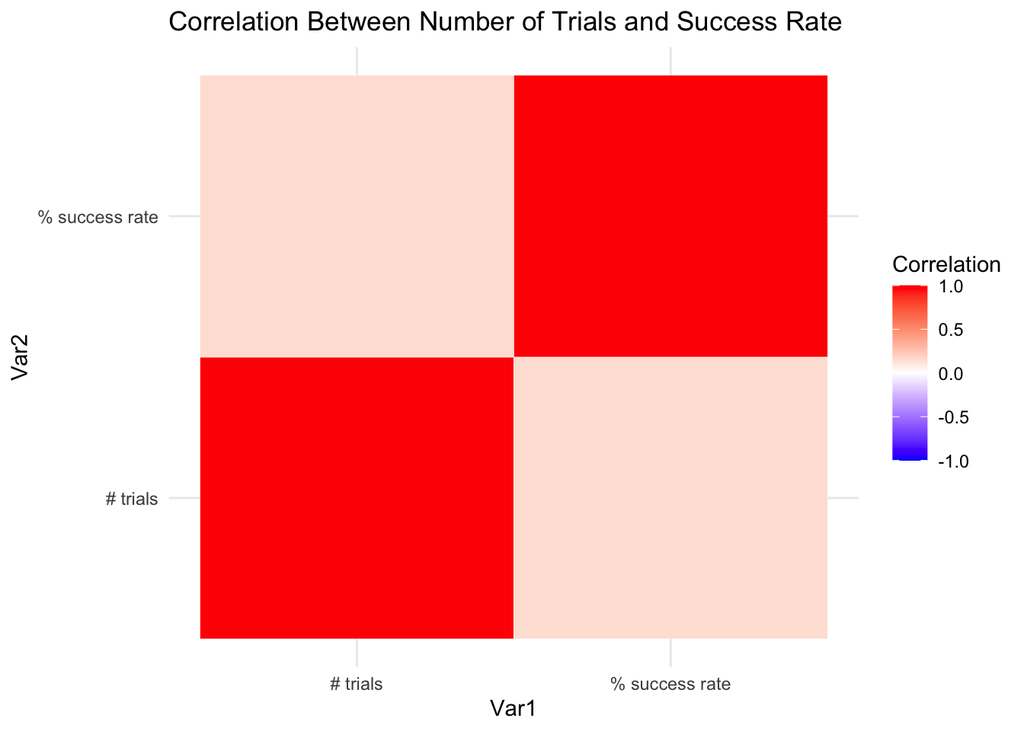

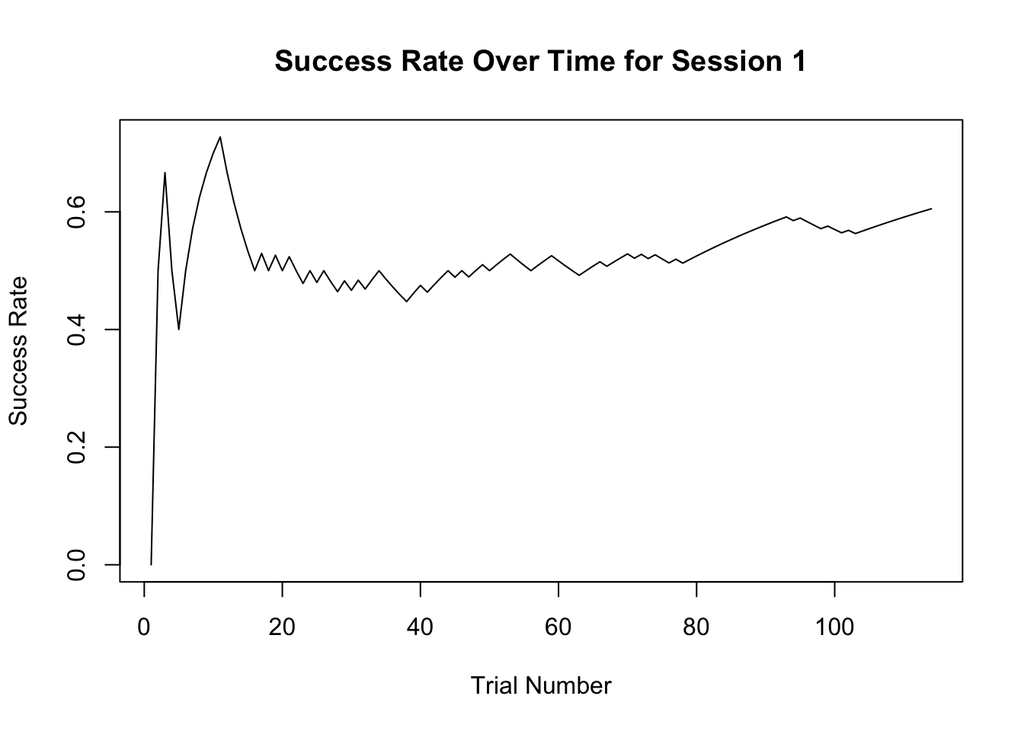

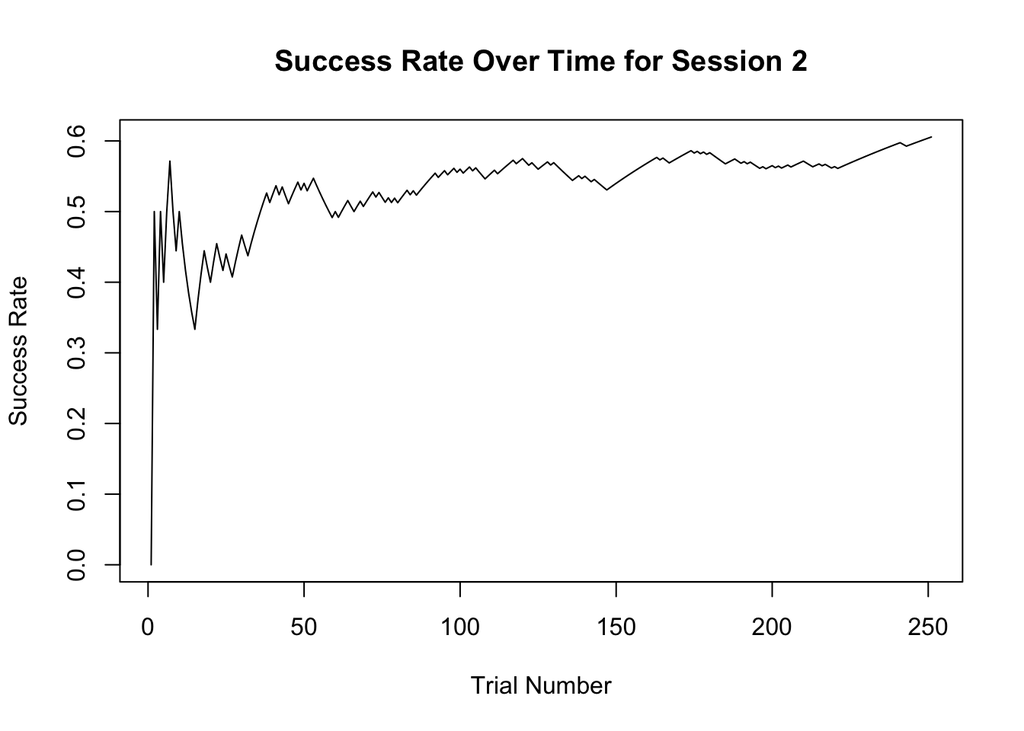

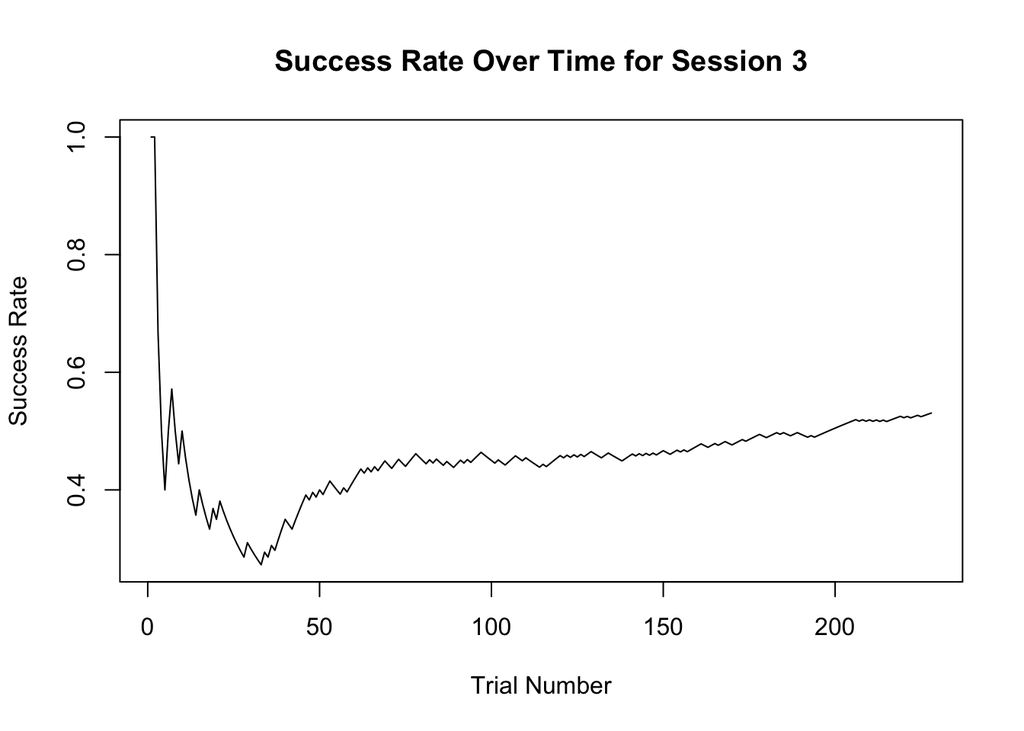

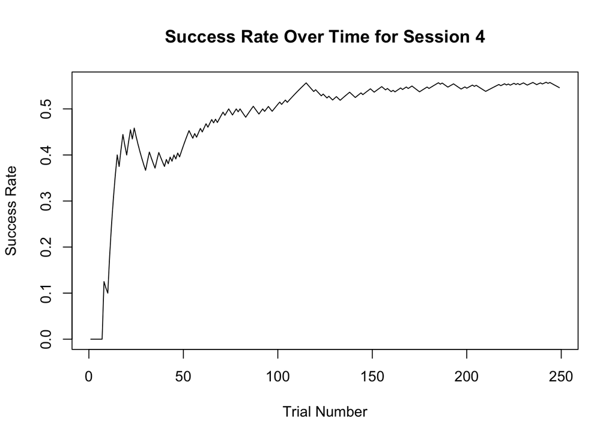

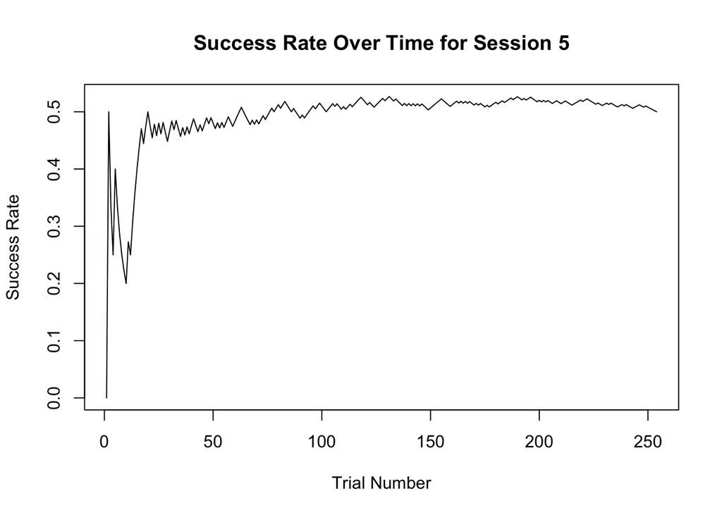

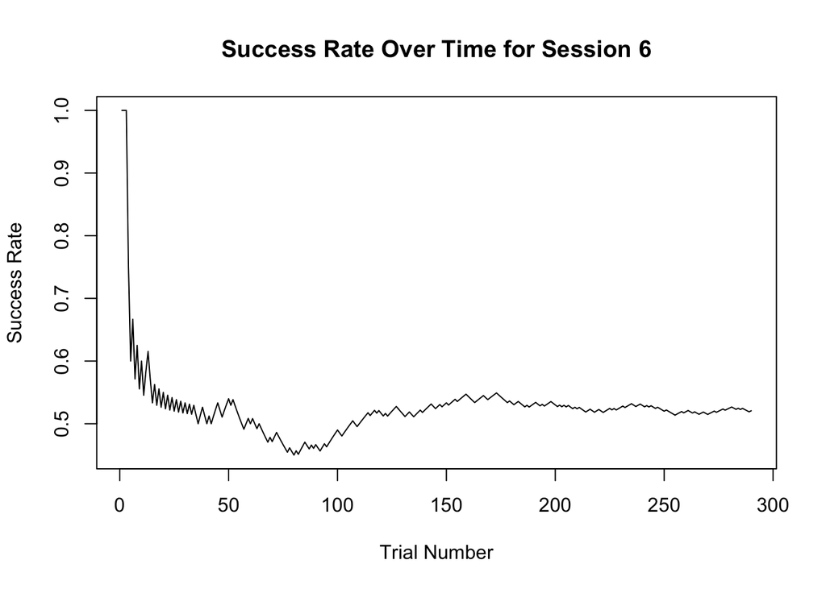

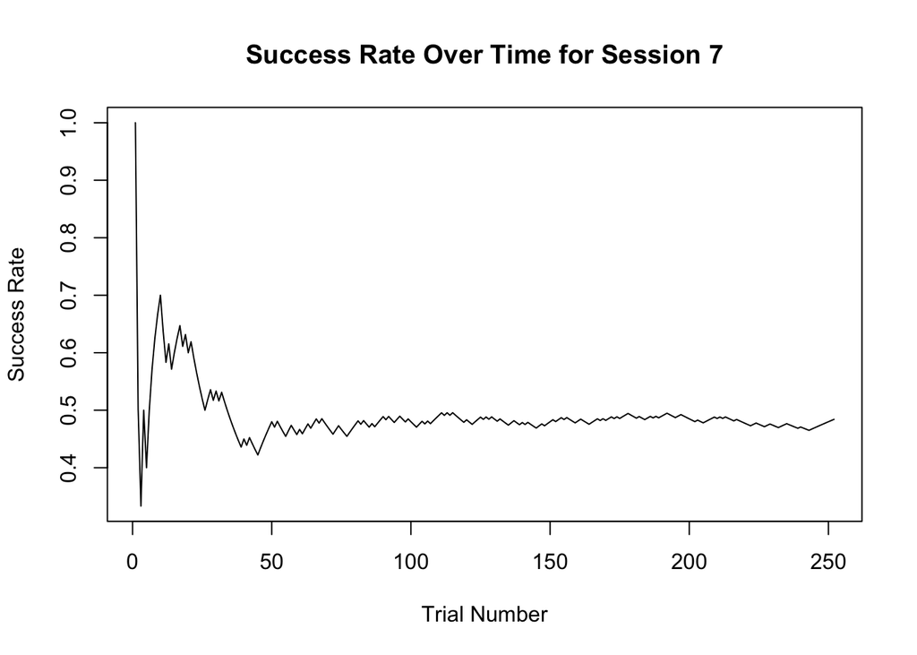

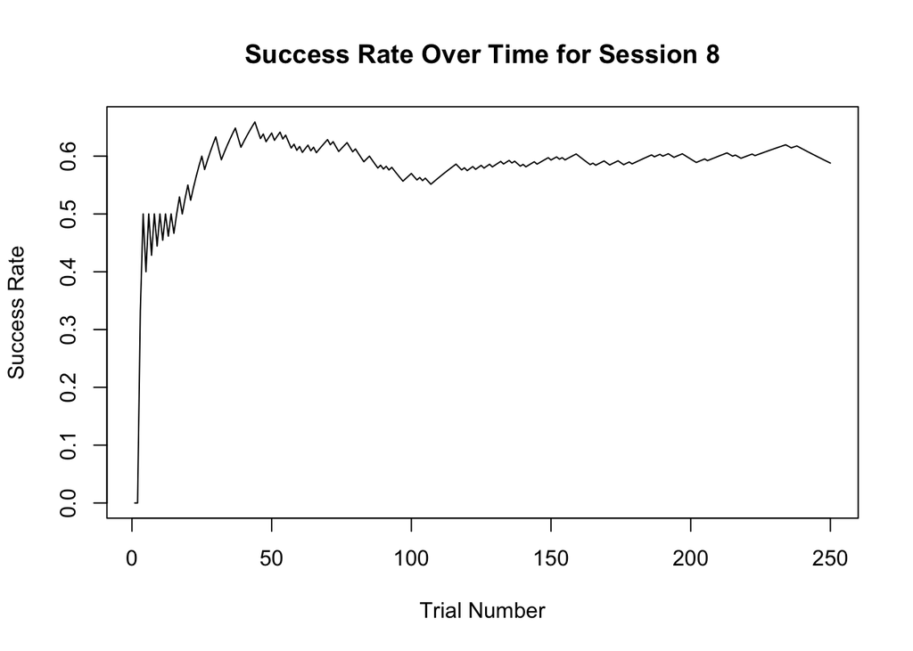

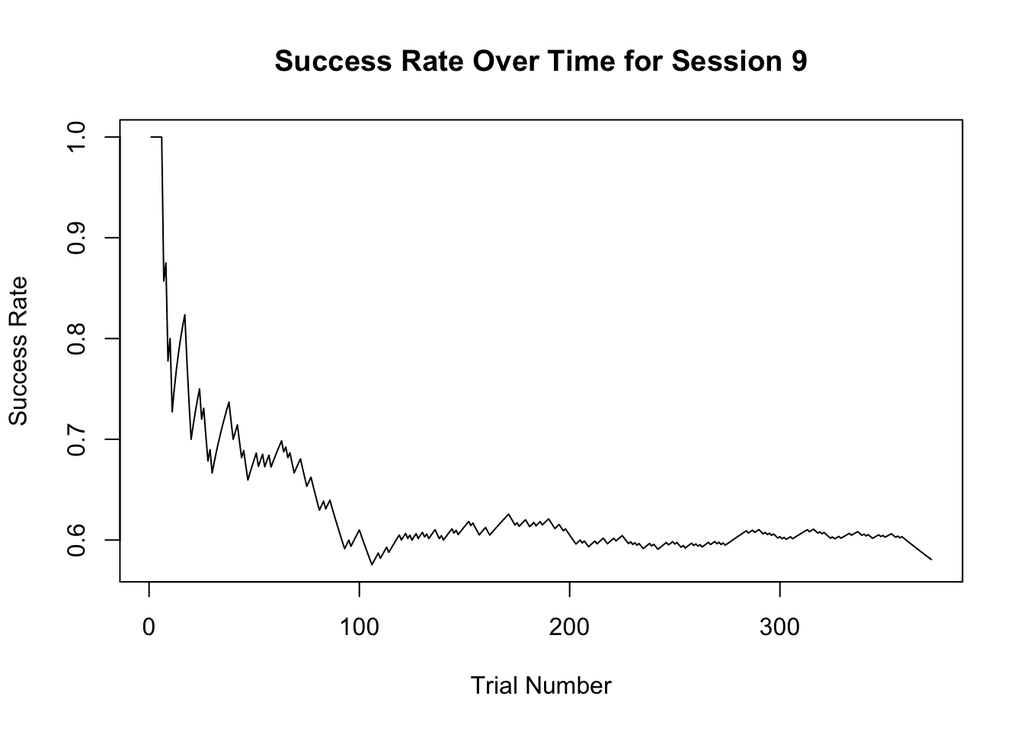

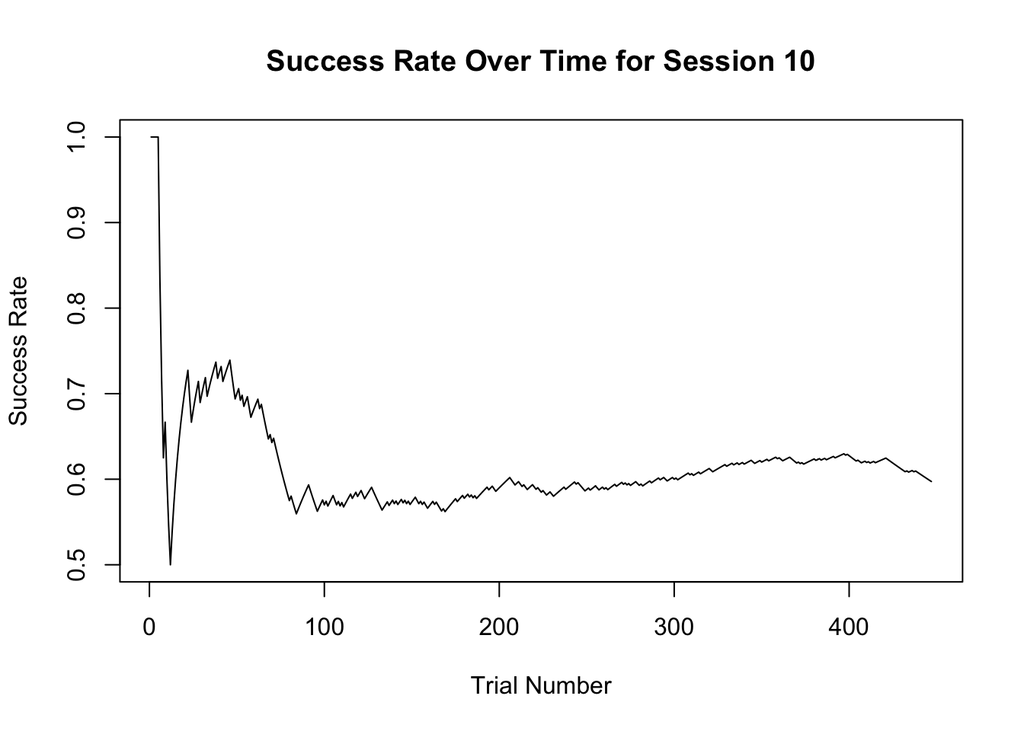

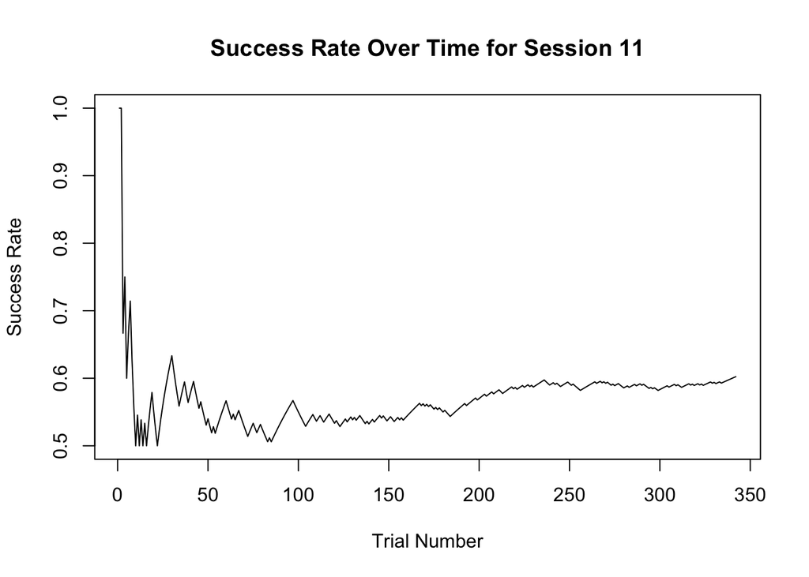

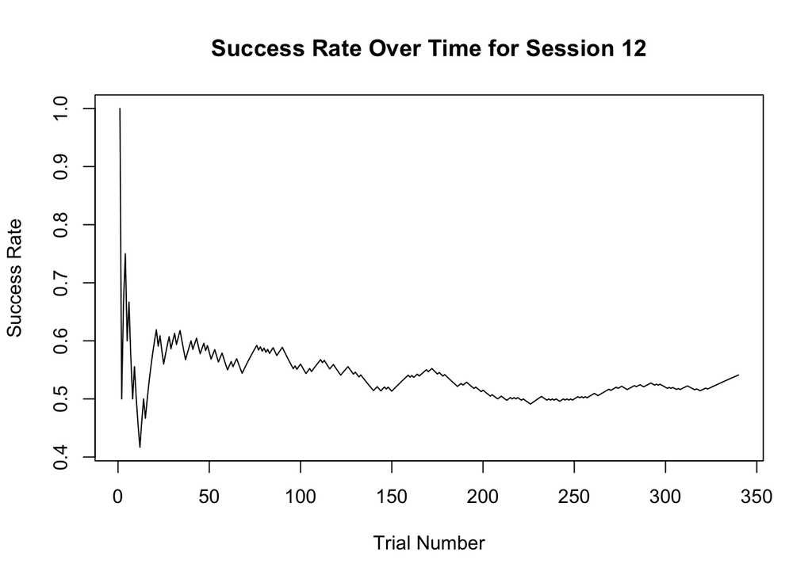

[6 more figures not shown]

```r
# Calculate success rate for each trial
success_rate_per_trial <- lapply(session, function(sess) {
  # Extract relevant variables for each session
  trials <- data.frame(
    contrast_left = unlist(sess$contrast_left),
    contrast_right = unlist(sess$contrast_right),
    feedback_type = unlist(sess$feedback_type)
  )

  # Define a function to determine success based on feedback type and contrasts
  determine_success <- function(left_contrast, right_contrast, feedback_type) {
    if (left_contrast > right_contrast && feedback_type == 1) {
      return(1)  # Success
    } else if (left_contrast < right_contrast && feedback_type == -1) {
      return(1)  # Success
    } else if (left_contrast == 0 && right_contrast == 0 && feedback_type == 1) {
      return(1)  # Success
    } else if (left_contrast == right_contrast && left_contrast != 0 && feedback_type == 1) {
      return(1)  # Success
    } else {
      return(0)  # Failure
    }
  }

  # Apply the determine_success function to each trial
  trials$success <- mapply(determine_success, trials$contrast_left, trials$contrast_right, trials$feedback_type)

  # Calculate success rate for each trial
  success_rate <- cumsum(trials$success) / seq_along(trials$success)

  # Return success rate for each trial
  return(success_rate)
})

# Plot success rate over time for individual sessions
plot_success_rate <- function(success_rate, session_number) {
  plot(success_rate, type = "l", xlab = "Trial Number", ylab = "Success Rate",
       main = paste("Success Rate Over Time for Session", session_number))
}


# Plot success rate for each session
for (i in 1:length(success_rate_per_trial)) {

  plot_success_rate(success_rate_per_trial[[i]], i)

}
```

These plot shows the success rate for each trial within each session. I noticed that after the 50th trials, the graph tend to converge to a constant which in most cases it tend to be around 0.6.

```r
#full_functional_tibble %>% group_by(mouse_name) %>% summarize(success_rate = mean(success, na.rm = TRUE))
```

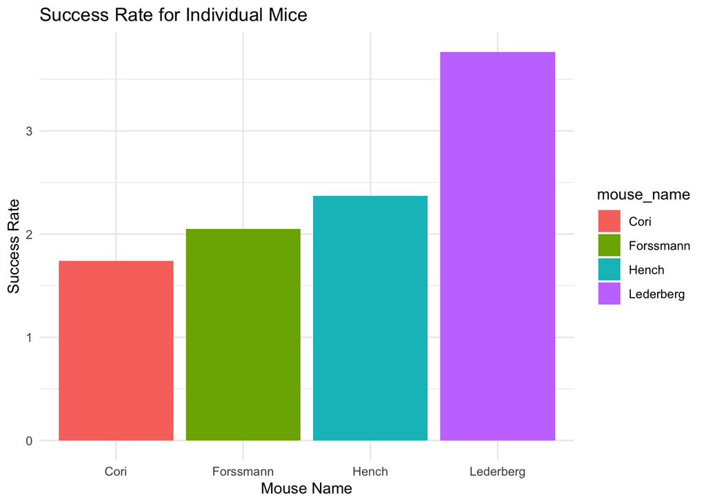

```r
mouse_success_rates <- data.frame(
  mouse_name = character(),
  success_rate = double()
)

# Calculate success rate for each mouse
for (i in 1:length(success_rate_per_trial)) {
  mouse_name <- session[[i]]$mouse_name[1]
  success_rate <- tail(success_rate_per_trial[[i]], 1)  # Take the final success rate
  mouse_success_rates <- rbind(mouse_success_rates, data.frame(mouse_name = mouse_name, success_rate = success_rate))
}

# Plot success rate for individual mice
ggplot(mouse_success_rates, aes(x = mouse_name, y = success_rate, fill = mouse_name)) +
  geom_bar(stat = "identity") +
  labs(x = "Mouse Name", y = "Success Rate", title = "Success Rate for Individual Mice") +
  theme_minimal()
```

```
##      CA1     POST     root     VISl    VISpm
## 1.121053 1.816754 1.538462 1.398268 2.000000
```

This calculate teh average spike count for each brain area in a session.

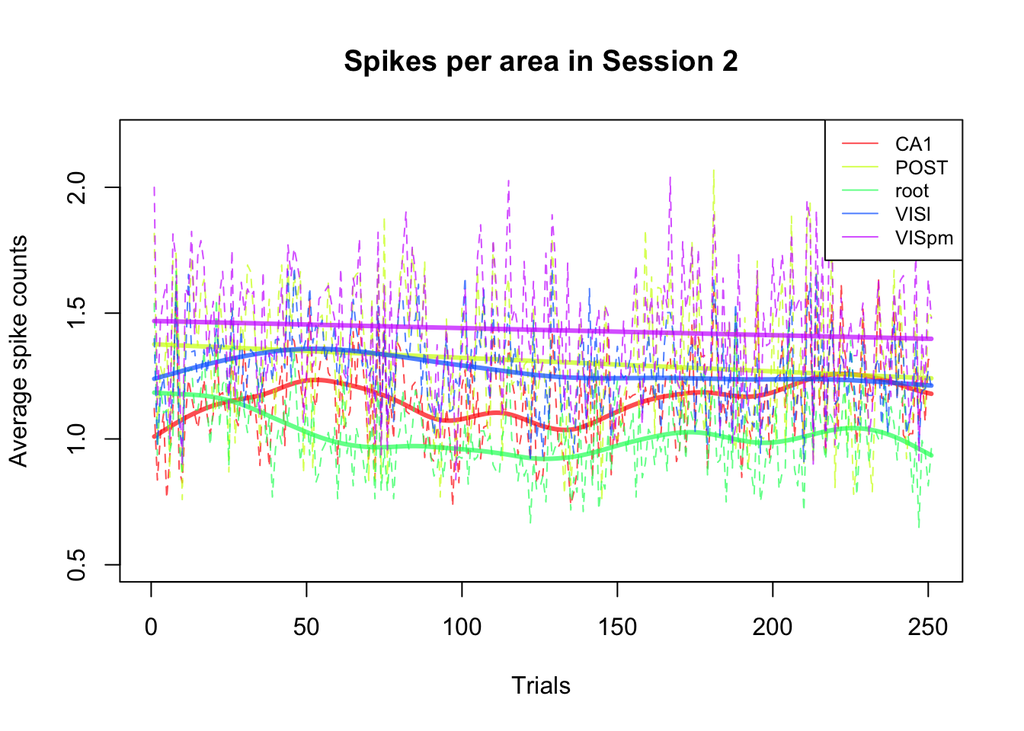

This plot shows the average spike counts for each neruon area across trials. This helps understand the activity level of different brain areas during the session 2. I noticed that the average spike count generally did not change as much as the numer of trails increase except for CA1 line and the root line.

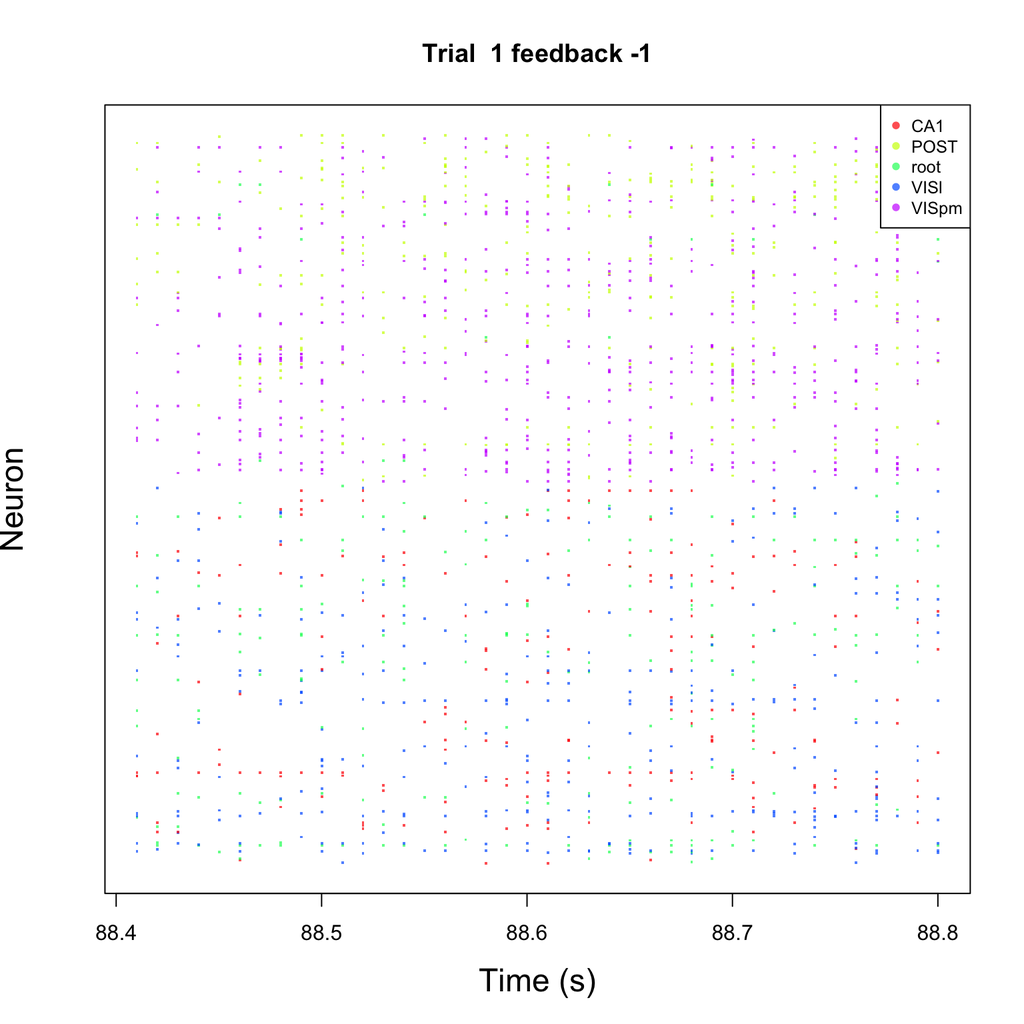

```r
varname=names(trial.summary);
area=varname[1:(length(varname)-4)]
plot.trial(1,area, area.col,session[[i.s]])
```

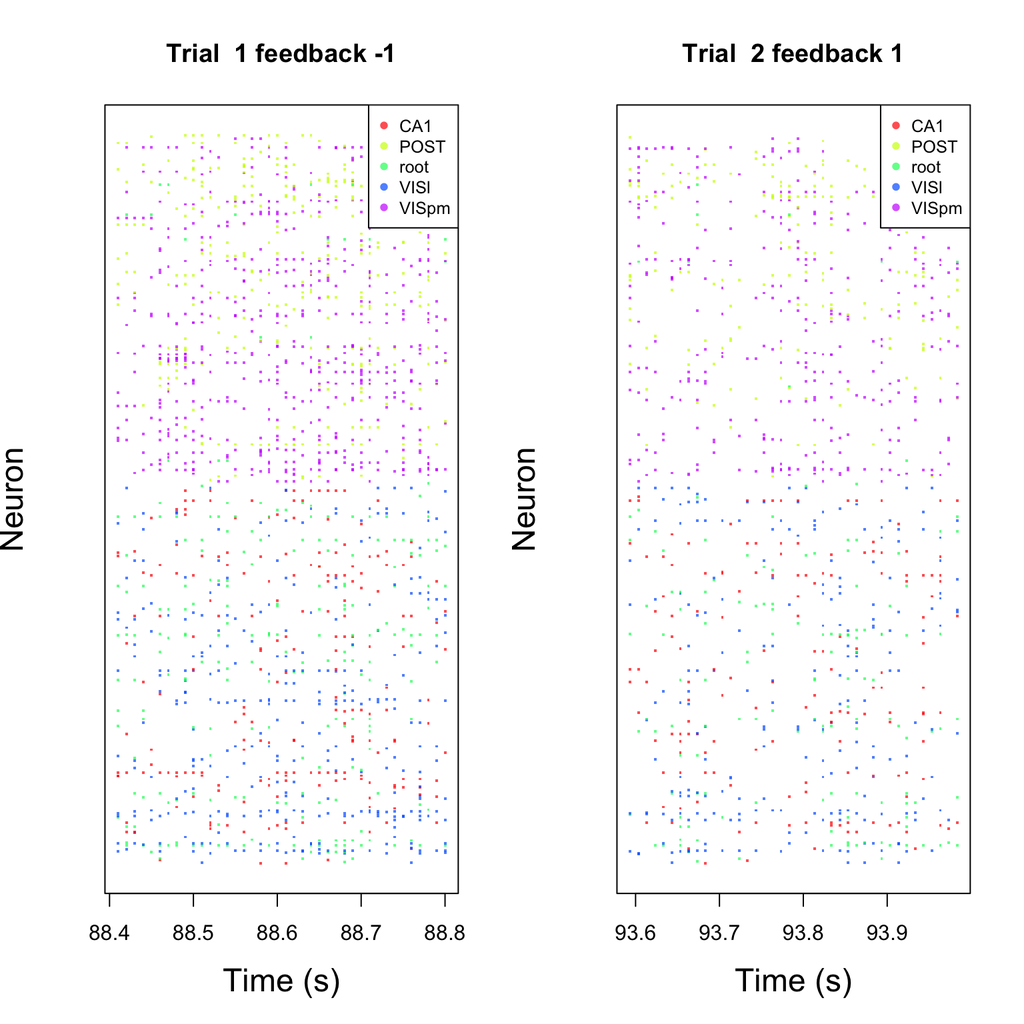

```r
varname=names(trial.summary);
area=varname[1:(length(varname)-4)]
par(mfrow=c(1,2))
plot.trial(1,area, area.col,session[[i.s]])
plot.trial(2,area, area.col,session[[i.s]])
```

```r
par(mfrow=c(1,1))
```

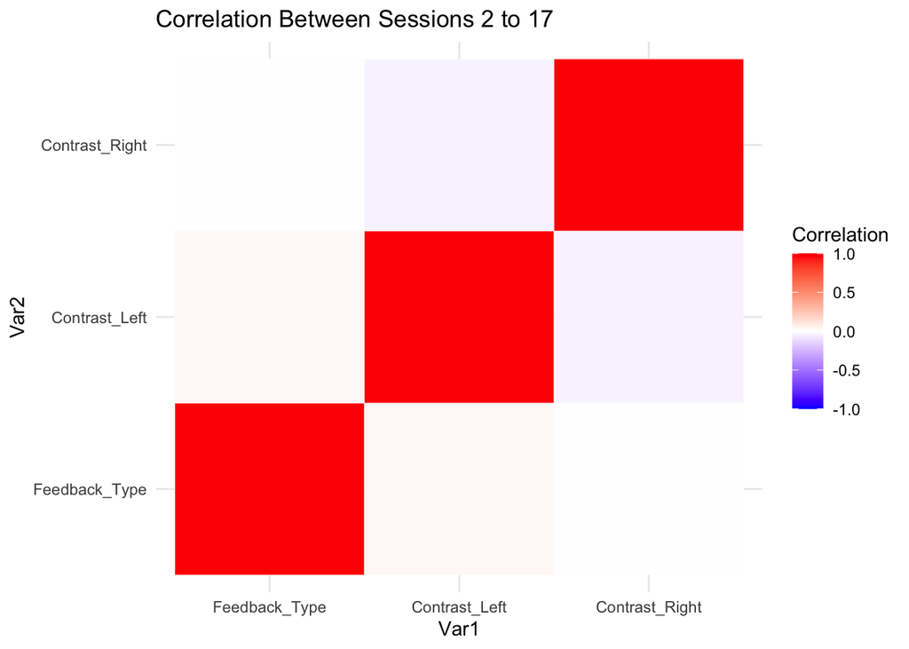

This correlation matrix shows the feedback type, contrast left and right in the graph. We can see that there is weak correlation between contrast left and contrast right for the sessions 2 to 17. There are almost no correlation between feedback type and ocntrast right.

# Data Integration

```r
predictive_feature <- c("session_id","trail_id","contrast_right","contrast_left", "contrast_diff" ,binename)
head(full_functional_tibble[predictive_feature])
```

```
## # A tibble: 6 × 45
##   session_id trail_id contrast_right contrast_left contrast_diff   bin1   bin2
##   <fct>         <int>          <dbl>         <dbl>         <dbl>  <dbl>  <dbl>
## 1 1                 1            0.5           0             0.5 0.0490 0.0368
## 2 1                 2            0             0             0   0.0300 0.0313
## 3 1                 3            1             0.5           0.5 0.0490 0.0504
## 4 1                 4            0             0             0   0.0559 0.0531
## 5 1                 5            0             0             0   0.0272 0.0436
## 6 1                 6            0             0             0   0.0490 0.0218
## # ℹ 38 more variables: bin3 <dbl>, bin4 <dbl>, bin5 <dbl>, bin6 <dbl>,
## #   bin7 <dbl>, bin8 <dbl>, bin9 <dbl>, bin10 <dbl>, bin11 <dbl>, bin12 <dbl>,
## #   bin13 <dbl>, bin14 <dbl>, bin15 <dbl>, bin16 <dbl>, bin17 <dbl>,
## #   bin18 <dbl>, bin19 <dbl>, bin20 <dbl>, bin21 <dbl>, bin22 <dbl>,
## #   bin23 <dbl>, bin24 <dbl>, bin25 <dbl>, bin26 <dbl>, bin27 <dbl>,
## #   bin28 <dbl>, bin29 <dbl>, bin30 <dbl>, bin31 <dbl>, bin32 <dbl>,
## #   bin33 <dbl>, bin34 <dbl>, bin35 <dbl>, bin36 <dbl>, bin37 <dbl>, …
```

This table shows the trails from all session and the variables name on the top is the average spike rate of each time bin.

```r
predictive_dat <- full_functional_tibble[predictive_feature]
#predictive_dat$success <- as.numeric(predictive_dat$success)
predictive_dat$trail_id <- as.numeric(predictive_dat$trail_id)
label <- as.numeric(full_functional_tibble$success)
X <- model.matrix(~., predictive_dat)
```

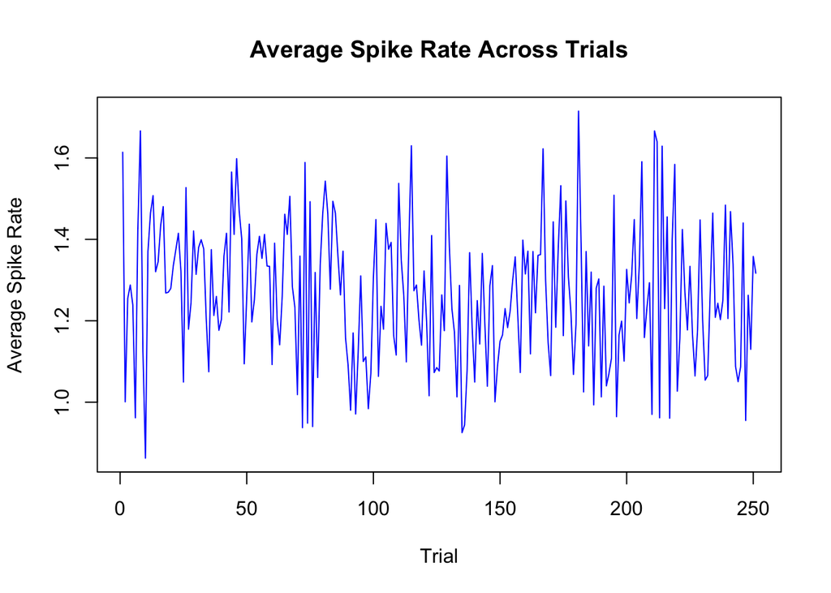

By examining the line plot, the overall trend in the spike rate are shown in above. The line plot shows that the average spike rate varies across the trials, therefore, we can not say there are noticeable trends.

| mouse_name | date_exp | n_brain_area | n_neurons | n_trials | success_rate |
| --- | --- | --- | --- | --- | --- |
| Cori | 2016-12-14 | 8 | 734 | 114 | 0.61 |
| Cori | 2016-12-17 | 5 | 1070 | 251 | 0.63 |
| Cori | 2016-12-18 | 11 | 619 | 228 | 0.66 |
| Forssmann | 2017-11-01 | 11 | 1769 | 249 | 0.67 |

```
## [1] 1.581744
```

```
## [1] 1.581744
```

```
## [1] 3.806557
```

```
## [1] NaN
```

| Metric | Average Spike Count |
| --- | --- |
| First Trial in Session 1 | 1.58 |
| Per Active Neuron | 3.81 |
| Per Neuron in TH | NaN |

This table shows the avergae number of spikes per neuron in the first 0.4 seconds of trial 1 in session 1, average number of spikes per active neuron and the average number of spikes per neurons in the specified brain area.

# Model Training and Prediction

```
##  feedback_type decision   avg_spikes
##  -1: 42        1:72     Min.   :0.6872
##  1 :174        2:71     1st Qu.:1.0055
##                3:63     Median :1.1050
##                4:10     Mean   :1.0964
##                         3rd Qu.:1.2060
##                         Max.   :1.5284
```

This table tells us about the characteristics of the feedback type, decisions, and the average spikes varaibke in session 18.

```r
# Split data into train and test
set.seed(101)
sample <- sample.int(n = n_obs, size = floor(.8 * n_obs), replace = F)
train <- dat[sample, ]
test  <- dat[-sample, ]
```

```
##
## Call:
## glm(formula = feedback_type ~ ., family = "binomial", data = train)
##
## Deviance Residuals:
##     Min       1Q   Median       3Q      Max
## -2.4607   0.3115   0.4090   0.5674   1.5112
##
## Coefficients:
##             Estimate Std. Error z value Pr(>|z|)
## (Intercept)  -3.1945     1.5730  -2.031  0.04227 *
## decision2    -0.2750     0.6230  -0.441  0.65892
## decision3    -0.7646     0.5300  -1.443  0.14915
## decision4    -3.1867     0.8569  -3.719  0.00020 ***
## avg_spikes    4.9317     1.5257   3.232  0.00123 **
## ---
## Signif. codes:  0 '***' 0.001 '**' 0.01 '*' 0.05 '.' 0.1 ' ' 1
##
## (Dispersion parameter for binomial family taken to be 1)
##
##     Null deviance: 165.27  on 171  degrees of freedom
## Residual deviance: 137.34  on 167  degrees of freedom
## AIC: 147.34
##
## Number of Fisher Scoring iterations: 5
```

```
## [1] 0.2272727
```

The shows that the prediction error is about 23%

```
## # A tibble: 6 × 12
##   feedback_type decision    CP   ACB    OT    SI   SNr   LGd    ZI   CA3  root
##   <fct>         <fct>    <dbl> <dbl> <dbl> <dbl> <dbl> <dbl> <dbl> <dbl> <dbl>
## 1 1             1        1.27  1.63  1.13  0.787 0.846  2.08  1.85 0.8    1.06
## 2 1             1        1.16  1.4   1.12  1.04  0.577  1.86  2.19 1.06   1.41
## 3 -1            3        0.723 1.43  0.943 1.25  0.538  1.92  1.52 0.923  1.24
## 4 -1            3        0.890 0.829 0.652 1.16  0.423  1.65  1.81 0.815  1.02
## 5 1             3        0.729 1.26  0.582 0.989 0.346  2.36  1.67 0.885  1.36
## 6 1             1        0.981 1.43  0.810 0.719 0.808  1.94  1.96 0.823  1.25
## # ℹ 1 more variable: TH <dbl>
```

```
##
## Call:
## glm(formula = feedback_type ~ ., family = "binomial", data = train)
##
## Deviance Residuals:
##     Min       1Q   Median       3Q      Max
## -2.5193   0.1554   0.2999   0.5594   1.9914
##
## Coefficients:
##             Estimate Std. Error z value Pr(>|z|)
## (Intercept)  -1.8890     2.2237  -0.849 0.395618
## decision2    -0.2538     0.7222  -0.351 0.725250
## decision3    -1.4426     0.6522  -2.212 0.026982 *
## decision4    -3.6987     0.9971  -3.710 0.000208 ***
## CP            3.7749     2.5070   1.506 0.132144
## ACB          -0.3608     0.6038  -0.598 0.550105
## OT            1.8254     2.1131   0.864 0.387668
## SI            1.5682     1.0881   1.441 0.149503
## SNr          -1.7827     0.9467  -1.883 0.059700 .
## LGd           2.2555     1.2566   1.795 0.072671 .
## ZI           -2.8712     1.1066  -2.595 0.009473 **
## CA3           2.5892     1.3209   1.960 0.049967 *
## root          1.5494     1.6697   0.928 0.353443
## TH           -3.3211     1.6903  -1.965 0.049441 *
## ---
## Signif. codes:  0 '***' 0.001 '**' 0.01 '*' 0.05 '.' 0.1 ' ' 1
##
## (Dispersion parameter for binomial family taken to be 1)
##
##     Null deviance: 165.27  on 171  degrees of freedom
## Residual deviance: 118.94  on 158  degrees of freedom
## AIC: 146.94
##
## Number of Fisher Scoring iterations: 6
```

```
## [1] 0.25
```

```r
# split
set.seed(123) # for reproducibility
trainIndex <- createDataPartition(label, p = .8,
                                  list = FALSE,
                                  times = 1)
train_df <- predictive_dat[trainIndex, ]
train_X <- X[trainIndex,]
test_df <- predictive_dat[-trainIndex, ]
test_X <- X[-trainIndex,]

train_label <- label[trainIndex]
test_label <- label[-trainIndex]
```

```r
library(xgboost)
xgb_model <- xgboost(data = train_X, label = train_label, objective = "binary:logistic", nrounds=10)
```

I decieded to use xgboost because I have a lot of features, similarly to the Ta’s demo. The code demonstrates the process of splitting the data into training and test sets for binary classification.

```r
predictions <- predict(xgb_model, newdata = test_X)
predicted_labels <- as.numeric(ifelse(predictions > 0.5, 1, 0))
accuracy <- mean(predicted_labels == test_label)
accuracy
```

```
## [1] 0.7312992
```

```r
conf_matrix <- confusionMatrix(as.factor(predicted_labels), as.factor(test_label))
conf_matrix$table
```

```
##           Reference
## Prediction   0   1
##          0  76  52
##          1 221 667
```

```r
#install.packages("pROC")  # Install the pROC package
library(pROC)
auroc <- roc(test_label, predictions)
auroc
```

```
##
## Call:
## roc.default(response = test_label, predictor = predictions)
##
## Data: predictions in 297 controls (test_label 0) < 719 cases (test_label 1).
## Area under the curve: 0.7379
```

The above shows the prediction result for accuracy, confusion matrix, and auroc. Auroc helpes measure the performance of a binary classification model. Area under the curve is 0.7379 which means that our model with moderate discrimination ability and it suggest that there are some predictive power.

#This tests the data from session 18 on performances of 50 random trails.

```r
# split
set.seed(123) # for reproducibility
session_18_row <- which(full_functional_tibble$session_id==18)
testIndex <- sample(session_18_row, 50, replace = FALSE)
trainIndex <- 1:nrow(full_functional_tibble)
trainIndex <- trainIndex[!(trainIndex %in% testIndex)]

train_df <- predictive_dat[trainIndex, ]
train_X <- X[trainIndex,]
test_df <- predictive_dat[-trainIndex, ]
test_X <- X[-trainIndex,]

train_label <- label[trainIndex]
test_label <- label[-trainIndex]
```

```r
xgb_model <- xgboost(data = train_X, label = train_label, objective = "binary:logistic", nrounds=10)
predictions <- predict(xgb_model, newdata = test_X)
predicted_labels <- as.numeric(ifelse(predictions > 0.5, 1, 0))
accuracy <- mean(predicted_labels == test_label)
accuracy
```

```
## [1] 0.8
```

```r
conf_matrix <- confusionMatrix(as.factor(predicted_labels), as.factor(test_label))
conf_matrix$table
```

```
##           Reference
## Prediction  0  1
##          0  1  1
##          1  9 39
```

```r
auroc <- roc(test_label, predictions)
auroc
```

```
##
## Call:
## roc.default(response = test_label, predictor = predictions)
##
## Data: predictions in 10 controls (test_label 0) < 40 cases (test_label 1).
## Area under the curve: 0.6875
```

With an area under the curve of 0.6875, it suggest that our model has some discriminatory power and there can be room for improvement.

## This test the model’s performance on 50 random trails from session 1

```
## [1] 0.66
```

```
##           Reference
## Prediction  0  1
##          0  2  0
##          1 17 31
```

```
##
## Call:
## roc.default(response = test_label, predictor = predictions)
##
## Data: predictions in 19 controls (test_label 0) < 31 cases (test_label 1).
## Area under the curve: 0.6689
```

With an area under the curve of 0.6689, it suggest that our model has some discriminatory power and there can be room for improvement.

# Reference

(**) Side note, there are two of the same graph because I have changed the name of the 1st graph to the second.

Steinmetz, N.A., Zatka-Haas, P., Carandini, M. et al. Distributed coding of choice, action and engagement across the mouse brain. Nature 576, 266–273 (2019). https://doi.org/10.1038/s41586-019-1787-x

TA and professor’s code.